# METABRIC-Analyses in Qing et al. 2022, npj Breast Cancer, PMID: 36344517

# Validation analyses in METABRIC cohort

## Preparations

Set up libraries and themes:

```r
datapath <- "./data/"

library(genefu)
library(data.table)
library(dplyr)
```

```r
library(ggplot2)
th = theme_bw() + theme(
  panel.border = element_blank(),
  panel.grid.major = element_blank(),
  panel.grid.minor = element_blank(),
  axis.line = element_line(colour = "black")
) + theme(
  legend.position = 'none',
  axis.text.x = element_text(colour = "black", size = 12),
  axis.text.y = element_text(
    colour = "black",
    size = 12,
    hjust = 0.95
  ),
  axis.ticks = element_blank(),
  plot.title = element_text(hjust = 0.5, face = "bold"),
  axis.title = element_text(size = 12, face = "bold")
) + theme(
  strip.placement = "outside",
  plot.title = element_text(hjust = 0.5),
  strip.text.x = element_text(size = 12),
  strip.text.y = element_text(angle = 0, size = 10, face = "italic"),
  panel.spacing = unit(0.1, "lines"),
  strip.background = element_rect(fill = "#EEEEEE", color = "#FFFFFF")
)
```

## Load signatures of gene names:

```r
signature <- read.delim(paste0(datapath,"signatures.txt"), h=T)
sig_lists=list()
for(i in 1:dim(signature)[1]){
  sig_lists[as.character(signature$Short[i])]=list(
    as.character(strsplit(gsub(" ","",signature$Genes[i]),split=",")[[1]]))
}
```

## Import METABRIC expression data and clinical information

24368 genes in rows, 1980 samples in columns, first two columns: Hugo_Symbol and Entrez_Gene_Id.

```r
mb.expr <- read.delim("./data/data_expression.txt",h=T)
# Matrix from metabric expression data
mat.all <- as.matrix(mb.expr[,-(1:2)])
rownames(mat.all) <- mb.expr[,1]
anno <- as.matrix(mb.expr[,1:2])
colnames(anno)[2] <- "EntrezGene.ID"

# Read metabric clinical data file skipping first 5 rows with comments on variables
mb.clin <- read.delim("./data/data_clinical.txt",h=T, skip=5)
# adjust SAMPLE_ID to altered colnames: SAMPLE_ID2
mb.clin$SAMPLE_ID2 <- gsub("-", ".", mb.clin$SAMPLE_ID)
```

## Selection of ER positive tumors:

Select ER positive tumors using the “ThreeGene model” of Haibe-Kains, and restrict to those samples with IHC for ER

```r
clin.erp <- mb.clin[mb.clin$THREEGENE %in% c("ER+/HER2- High Prolif", "ER+/HER2- Low Prolif"), ]
clin.erp <- na.omit(clin.erp[clin.erp$ER_IHC=="pos", ])
```

Select expression data of ER positive tumors

```r
mat.erp <- mat.all[ , colnames(mat.all) %in% clin.erp$SAMPLE_ID2]
```

## Determine Recurrence Score

We use an adapted oncotypedx function from the genefu package leaving out the gene BAG1, which is not available in METABRIC expression data.

```r
source("./functions/oncotypedx2_withoutBAG1.R")
require(genefu)
data(sig.oncotypedx)
sig.oncotypedx = sig.oncotypedx[sig.oncotypedx$symbol!="BAG1",]
rs.mb.erp <- oncotypedx2(data= t(mat.erp), annot= anno, do.mapping=FALSE, verbose=TRUE)
# add RS to clinical data
clin.erp <- cbind(clin.erp, rs.mb.erp$score[clin.erp$SAMPLE_ID2])
colnames(clin.erp)[ncol(clin.erp)] <- "rs.score"
```

### Exclude high oncotypedx score samples

We exclude those 20% of samples with highest oncotypedx scoring:

```r
# Select a subset with rs.score < 80%-Quantile
clin.erp.lowint <- subset(clin.erp, subset= rs.score < as.numeric(quantile(rs.score, probs=0.8)))
```

## Analysis of Metabric cohort ERpos Low/Interm RS

```r
clin <- clin.erp.lowint
rownames(clin) <- clin$SAMPLE_ID2
mat <- mat.erp[,colnames(mat.erp)%in%clin$SAMPLE_ID2]
```

### Select young and old sample groups

```r
clin$type <- NA
clin$type[clin$AGE_AT_DIAGNOSIS>=55] <- "old"
clin$type[clin$AGE_AT_DIAGNOSIS<=50] <- "young"
clin$type <- as.factor(clin$type)
clin <- clin[!is.na(clin$type),]
clin <- clin[order(rownames(clin)),]
mat <- mat[,colnames(mat) %in% rownames(clin)]
mat <- mat[,order(colnames(mat))]
```

### Estimate expression signatures

```r
mat_signature=NULL
for(sig in names(sig_lists)){
  score=apply(mat[which(rownames(mat)%in%sig_lists[[sig]]),],2,mean,na.rm=TRUE)
  mat_signature=rbind(mat_signature,score)
}
rownames(mat_signature) <- names(sig_lists)
#zscore normalized signatures
mat_signature_zscore=as.data.frame(apply(mat_signature,1,function(x)(x-mean(x))/sd(x)),na.rm=TRUE)
mat_signature_zscore=cbind(rownames(mat_signature_zscore), mat_signature_zscore)
colnames(mat_signature_zscore)[1] <- "SAMPLE_ID2"
finalMat=merge(clin,mat_signature_zscore,by="SAMPLE_ID2")
```

### Scatter plots for correlation between signatures in Suppl.Fig.4, METABRIC cohort:

```r
library(psych)
```

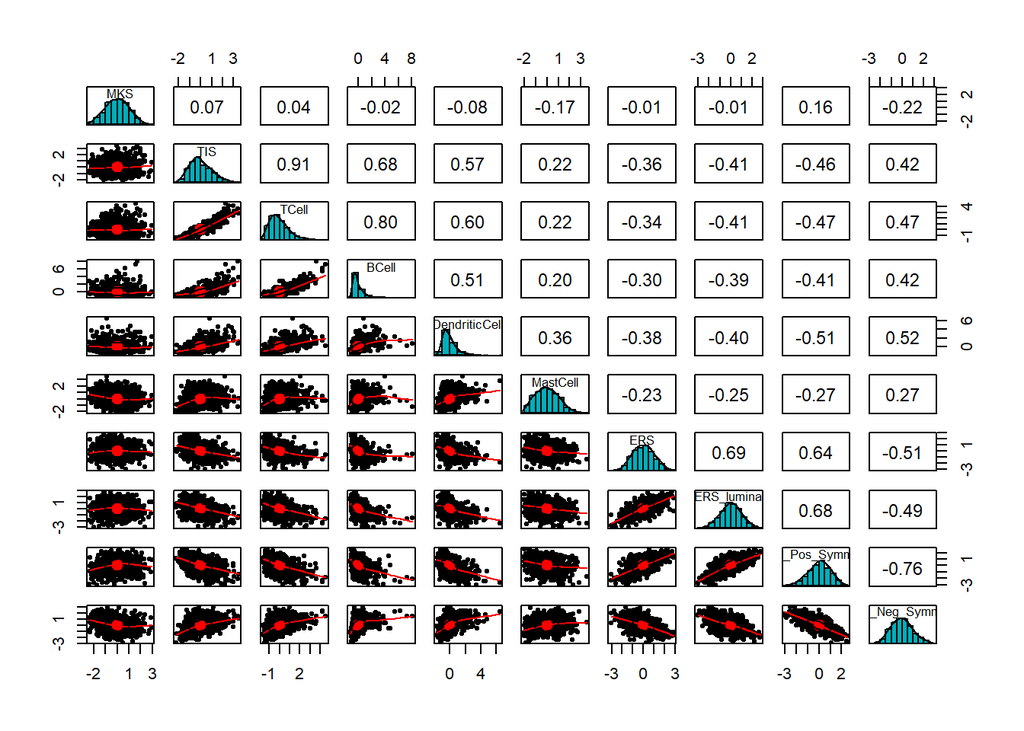

```r
pairs.panels(finalMat%>%dplyr::select("MKS","TIS","TCell","BCell","DendriticCell","MastCell","ERS","ERS_luminal","ERS_Pos_Symmans","ERS_Neg_Symmans")%>%mutate_all(~as.numeric(as.matrix(.))),
             method = "pearson", # correlation method
             hist.col = "#00AFBB",
             density = TRUE,  # show density plots
             ellipses = TRUE, # show correlation ellipses
             cex=1
)
```

### Comparison of signatures in young vs old by Mann-Whitney test (Table 2, METABRIC Cohort)

```r
ttMW=NULL
for(s in rownames(mat_signature)){
  submat=finalMat[,c("type",s)]
  submat[,s]=as.numeric(as.matrix(submat[,s]))

  pvalue=wilcox.test(submat[submat$type=="young",s],submat[submat$type=="old",s])$p.value
  tmpmean=tapply(submat[,s],submat$type,mean)
  ttMW=rbind(ttMW,cbind(Signature=s,'log2 Fold Change'=as.numeric(tmpmean["young"])-as.numeric(tmpmean["old"]),'Mean in Young'=tmpmean["young"],'Mean in Old'=tmpmean["old"],Pvalue=pvalue))
}

ttMW=as.data.frame(ttMW)
ttMW$Pvalue=as.numeric(as.matrix(ttMW$Pvalue))
ttMW$FDR=p.adjust(ttMW$Pvalue,method="fdr")

ttMW$`log2 Fold Change`=as.numeric(as.matrix(ttMW$`log2 Fold Change`))
ttMW$`Mean in Young`=as.numeric(as.matrix(ttMW$`Mean in Young`))
ttMW$`Mean in Old`=as.numeric(as.matrix(ttMW$`Mean in Old`))

ttMW
```

|  | Signature | log2 Fold Change | Mean in Young | Mean in Old | Pvalue | FDR |
| --- | --- | --- | --- | --- | --- | --- |
| young | MKS | -0.08227795 | -0.06711898 | 0.015158973 | 2.908694e-01 | 3.231882e-01 |
| young.1 | TIS | 0.08653064 | 0.07058814 | -0.015942493 | 2.891031e-01 | 3.231882e-01 |
| young.2 | TCell | 0.16799337 | 0.13704210 | -0.030951269 | 1.406110e-02 | 2.812219e-02 |
| young.3 | BCell | 0.19709744 | 0.16078401 | -0.036313434 | 8.196295e-06 | 4.098147e-05 |
| young.4 | DendriticCell | 0.03486033 | 0.02843762 | -0.006422702 | 3.561561e-01 | 3.561561e-01 |
| young.5 | MastCell | 0.17682335 | 0.14424524 | -0.032578114 | 3.539566e-02 | 5.899276e-02 |
| young.6 | ERS | -0.37902411 | -0.30919232 | 0.069831789 | 1.409728e-05 | 4.699095e-05 |
| young.7 | ERS_luminal | -0.17205231 | -0.14035322 | 0.031699093 | 6.028327e-02 | 8.611895e-02 |
| young.8 | ERS_Pos_Symmans | -0.25811623 | -0.21056064 | 0.047555598 | 1.379326e-03 | 3.448316e-03 |
| young.9 | ERS_Neg_Symmans | 0.59984353 | 0.48932774 | -0.110515783 | 4.358994e-12 | 4.358994e-11 |

## Heatmap of common differentially expressed genes in younger versus older cases (Suppl.Fig.5, METABRIC Cohort)

Import list of differentially expressed genes common between TCGA-cohort, Affy-Cohort-A, and Affy-Cohort-B.

```r
comm39.genes <- read.delim(paste0(datapath,"Common39Genes-probesets.txt"),h=T)
```

Combine a plot-matrix with genes in rows and samples in columns:

```r
plotMat <- mat[rownames(mat) %in% comm39.genes$Gene,]
type <- clin$type  #type is a character array of age group
plotMat <- plotMat[,order(clin$AGE_AT_DIAGNOSIS)] # reorder columns by patients age
type <- type[order(clin$AGE_AT_DIAGNOSIS)]  # reorder columns by patients age
# scale each gene
plotMat <- t(scale(t(plotMat)))
```

Plot matrix as heatmap:

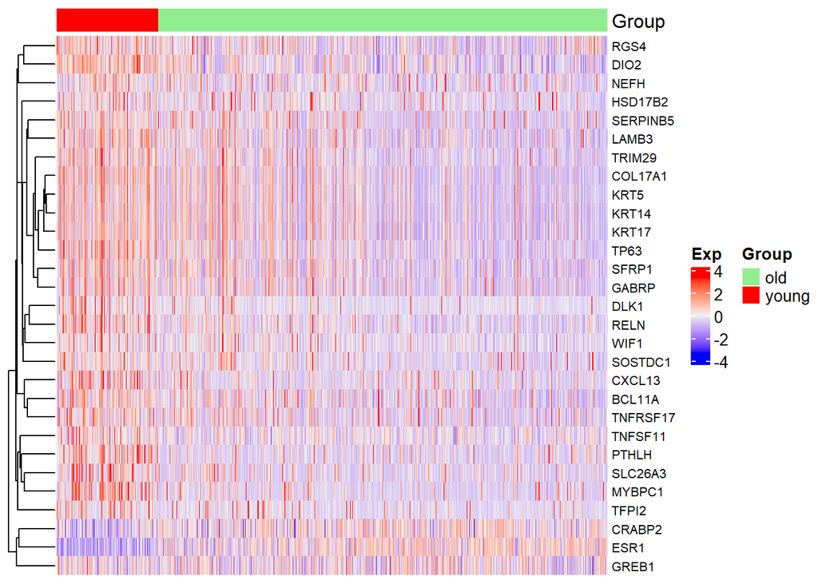

```r
require("ComplexHeatmap")
comm.heatmap=Heatmap(as.matrix(plotMat),name = "Exp",
                  top_annotation = HeatmapAnnotation(Group=type,col=list(Group=c("old"="lightgreen","young"="red"))),
                  show_row_names=TRUE,
                  row_names_gp = gpar(fontsize = 8),
                  show_column_names = FALSE,
                  cluster_columns = FALSE
)
plot(comm.heatmap)
```